# 和之前一样，将基因家族内的单个基因和gff3文件比对到一起，并对每个基因打上其所在基因家族label，label按照数字标记

```python
!ls csv
```

```
all_DIY.gff3  compare_selene_panicle_20samples.bed  gene_list.bed
all_DIY.gtf   distinct_families.txt		    gene_name.txt
all.pfam      famInfo.table.txt
```

```python
!head ./csv/all.pfam
```

```
model	hmm_acc	hmm_name	hmm_type	bit_score	evalue	prot_match_start	prot_match_end	hmm_match_start	hmm_match_end
LOC_Os01g01010.1	PF00566.11	TBC	Family	111.5	3e-32	390	536	47	193
LOC_Os01g01010.2	PF00566.11	TBC	Family	111.8	2.4e-32	390	536	47	193
LOC_Os01g01030.1	PF00394.15	Cu-oxidase	Domain	130	5.4e-38	166	317	2	154
LOC_Os01g01030.1	PF07731.7	Cu-oxidase_2	Domain	89.4	9.5e-26	411	539	11	129
LOC_Os01g01030.1	PF07732.8	Cu-oxidase_3	Domain	123.1	3.9e-36	45	152	10	118
LOC_Os01g01050.1	PF01424.15	R3H	Family	37.8	8.7e-10	87	125	14	52
LOC_Os01g01050.2	PF01424.15	R3H	Family	37.9	7.9e-10	64	102	14	52
LOC_Os01g01060.1	PF00177.14	Ribosomal_S7	Domain	141.6	9.9e-42	46	200	2	148
LOC_Os01g01070.2	PF07889.5	DUF1664	Family	169.3	2.2e-50	92	213	4	126
```

```python
import numpy as np
import seaborn as sns
import matplotlib.pyplot as plt
import pandas as pd

all_gtf_list = pd.read_csv('./csv/all_DIY.gff3',sep='\t',
               names = ['chrom', 'extra', 'site', 'start', 'end', 'score', 'a', 'b', 'explanation'])
all_gtf_gene_list = all_gtf_list.query("site == 'gene'")
all_gtf_gene_list.chrom.unique()
all_gtf_gene_list
```

|  | chrom | extra | site | start | end | score | a | b | explanation |
| --- | --- | --- | --- | --- | --- | --- | --- | --- | --- |
| 1 | chr01 | MSU_osa1r7 | gene | 2903.0 | 10817.0 | . | + | . | ID=LOC_Os01g01010;Name=LOC_Os01g01010;Note=TBC... |
| 55 | chr01 | MSU_osa1r7 | gene | 11218.0 | 12435.0 | . | + | . | ID=LOC_Os01g01019;Name=LOC_Os01g01019;Note=exp... |
| 63 | chr01 | MSU_osa1r7 | gene | 12648.0 | 15915.0 | . | + | . | ID=LOC_Os01g01030;Name=LOC_Os01g01030;Note=mon... |
| 77 | chr01 | MSU_osa1r7 | gene | 16292.0 | 20323.0 | . | + | . | ID=LOC_Os01g01040;Name=LOC_Os01g01040;Note=exp... |
| 142 | chr01 | MSU_osa1r7 | gene | 22841.0 | 26971.0 | . | + | . | ID=LOC_Os01g01050;Name=LOC_Os01g01050;Note=R3H... |
| ... | ... | ... | ... | ... | ... | ... | ... | ... | ... |
| 813767 | chr14 | MSU_osa1r7 | gene | 572904.0 | 573515.0 | . | + | . | ID=chr14.fgenesh.gene.85;Name=chr14.fgenesh.ge... |
| 813771 | chr14 | MSU_osa1r7 | gene | 573737.0 | 574348.0 | . | - | . | ID=chr14.fgenesh.gene.86;Name=chr14.fgenesh.ge... |
| 813775 | chr14 | MSU_osa1r7 | gene | 576385.0 | 580092.0 | . | + | . | ID=chr14.fgenesh.gene.87;Name=chr14.fgenesh.ge... |
| 813779 | chr14 | MSU_osa1r7 | gene | 585817.0 | 586479.0 | . | - | . | ID=chr14.fgenesh.gene.88;Name=chr14.fgenesh.ge... |
| 813785 | chr14 | MSU_osa1r7 | gene | 589676.0 | 589999.0 | . | + | . | ID=chr14.fgenesh.gene.89;Name=chr14.fgenesh.ge... |

55986 rows × 9 columns

```python
ricev7_all_famInfo = pd.read_csv("./csv/all.pfam",sep='\t')
print(ricev7_all_famInfo.columns)
ricev7_all_famInfo_gene_and_gene_family = ricev7_all_famInfo.reindex(columns=['model','hmm_acc'])
ricev7_all_famInfo_gene_and_gene_family = ricev7_all_famInfo_gene_and_gene_family.loc[ricev7_all_famInfo.model.str.contains('LOC_')]
ricev7_all_famInfo_gene_and_gene_family.columns = ['gene', 'gene_family']
for i in range(len(ricev7_all_famInfo_gene_and_gene_family)):
    gene_ = ricev7_all_famInfo_gene_and_gene_family.iloc[i]['gene']
    gene_family_ = ricev7_all_famInfo_gene_and_gene_family.iloc[i]['gene_family']
    gene_modify = ''
    gene_family_modify = ''
    for j in range(len(gene_)):
        if gene_[j] == '.':
            break
        else:
            gene_modify = gene_modify + gene_[j]
    for j in range(len(gene_family_)):
        if gene_family_[j] == '.':
            break
        else:
            gene_family_modify = gene_family_modify + gene_family_[j]
    ricev7_all_famInfo_gene_and_gene_family.iloc[i]['gene'] = gene_modify
    ricev7_all_famInfo_gene_and_gene_family.iloc[i]['gene_family'] = gene_family_modify
    print('%d'%(i),end='\r')

ricev7_all_famInfo_gene_and_gene_family
```

```
Index(['model', 'hmm_acc', 'hmm_name', 'hmm_type', 'bit_score', 'evalue',
       'prot_match_start', 'prot_match_end', 'hmm_match_start',
       'hmm_match_end'],
      dtype='object')
73989
```

|  | gene | gene_family |
| --- | --- | --- |
| 0 | LOC_Os01g01010 | PF00566 |
| 1 | LOC_Os01g01010 | PF00566 |
| 2 | LOC_Os01g01030 | PF00394 |
| 3 | LOC_Os01g01030 | PF07731 |
| 4 | LOC_Os01g01030 | PF07732 |
| ... | ... | ... |
| 73996 | LOC_Os12g44360 | PF00027 |
| 73997 | LOC_Os12g44380 | PF07690 |
| 73998 | LOC_Os12g44380 | PF07690 |
| 73999 | LOC_Os12g44390 | PF02463 |
| 74000 | LOC_Os12g44390 | PF06470 |

73990 rows × 2 columns

```python
print(
    len(ricev7_all_famInfo_gene_and_gene_family.gene.unique()),
    len(ricev7_all_famInfo_gene_and_gene_family.gene_family.unique())
)
#ricev7_all_famInfo_gene_and_gene_family.duplicated()
ricev7_all_famInfo_gene_and_gene_family.drop_duplicates()#去重复基因
```

```
33776 3333
```

|  | gene | gene_family |
| --- | --- | --- |
| 0 | LOC_Os01g01010 | PF00566 |
| 2 | LOC_Os01g01030 | PF00394 |
| 3 | LOC_Os01g01030 | PF07731 |
| 4 | LOC_Os01g01030 | PF07732 |
| 5 | LOC_Os01g01050 | PF01424 |
| ... | ... | ... |
| 73991 | LOC_Os12g44360 | PF00027 |
| 73992 | LOC_Os12g44360 | PF00999 |
| 73997 | LOC_Os12g44380 | PF07690 |
| 73999 | LOC_Os12g44390 | PF02463 |
| 74000 | LOC_Os12g44390 | PF06470 |

50752 rows × 2 columns

```python
out_file_all_genes = open('./ricev7_all_genes.txt','w')
for gene in ricev7_all_famInfo_gene_and_gene_family.gene.unique():
    out_file_all_genes.write('%s\n'%gene)
```

```python
ricev7_all_famInfo_gene_and_gene_family.loc[ricev7_all_famInfo_gene_and_gene_family.gene.str.contains('LOC_Os12g44360')]
```

|  | gene | gene_family |
| --- | --- | --- |
| 73991 | LOC_Os12g44360 | PF00027 |
| 73992 | LOC_Os12g44360 | PF00999 |
| 73993 | LOC_Os12g44360 | PF00999 |
| 73994 | LOC_Os12g44360 | PF00999 |
| 73995 | LOC_Os12g44360 | PF00999 |
| 73996 | LOC_Os12g44360 | PF00027 |

将基因家族文件和基因组注释文件结合获得一个公共信息表，内容包括基因、所属家族、在基因组上的位置

```python
from numpy import *
import h5py
import numpy as np
import pandas as pd
import sys
import subprocess
import matplotlib.pyplot as plt
import seaborn as sns

ricev7_gene_family_list = list(ricev7_all_famInfo_gene_and_gene_family.gene_family.unique())

def extract_gtf2bed(gff_gene_table, out_bed_file, target_list):
    out_file = open(out_bed_file,'w')
    #print(gtf_list['explanation'].head())
    for index in range(len(target_list)):#index为搜索当前基因
        sub_gff = gff_gene_table.loc[gff_gene_table.explanation.str.contains(target_list[index])]
        #range_list = []
        #搜索range min max
        '''
        for i in range(len(sub_gtf)):
            range_list.append(sub_gtf.iloc[i]['start'])
            range_list.append(sub_gtf.iloc[i]['end'])
        '''
        #print(range_list, min(range_list), max(range_list) )
        gene_family_ = list((ricev7_all_famInfo_gene_and_gene_family.loc[ricev7_all_famInfo_gene_and_gene_family.gene.str.contains(target_list[index])])['gene_family'])
        #if len(sub_gff['chrom'].unique()) == 1 and len(gene_family_) == 1:
        if len(sub_gff['chrom'].unique()) == 1:
            out_file.write("%s\t%d\t%d\t%s\t%s\t%s\n"%(sub_gff['chrom'].unique()[0], min(sub_gff.start), max(sub_gff.end), target_list[index], gene_family_[-1], ricev7_gene_family_list.index(gene_family_[-1])))
            print("Accomplished of index %d of %s, %s [%d %d] %d" % (index, target_list[index], sub_gff['chrom'].unique()[0], min(sub_gff.start), max(sub_gff.end), max(sub_gff.end)-min(sub_gff.start)), end='\r')
        else:
            print("%s ERROR ! "%(target_list[index]), end='\n')

extract_gtf2bed(all_gtf_gene_list, './csv/all_pfam_gene_and_gene_family_list.bed', ricev7_all_famInfo_gene_and_gene_family.gene.unique())
```

[output not shown]

# 不再通过计算Jaccard系数划分训练集，改用PCA降维后的KMeans结果来做

```python
!ls ./csv
```

```
all_DIY.gff3  all_pfam_gene_and_gene_family_list.bed  famInfo.table.txt
all_DIY.gtf   compare_selene_panicle_20samples.bed    gene_list.bed
all.pfam      distinct_families.txt		      gene_name.txt
```

```python
import numpy as np
import seaborn as sns
import matplotlib.pyplot as plt
import pandas as pd

gene_and_gene_family_label = pd.read_csv(
    './csv/all_pfam_gene_and_gene_family_list.bed',
    sep='\t',
    names = ['chrom', 'start', 'end', 'gene', 'gene_family', 'gene_family_label']
)
gene_and_gene_family_label['length'] = gene_and_gene_family_label['end'] - gene_and_gene_family_label['start']
gene_and_gene_family_label
```

|  | chrom | start | end | gene | gene_family | gene_family_label | length |
| --- | --- | --- | --- | --- | --- | --- | --- |
| 0 | chr01 | 2903 | 10817 | LOC_Os01g01010 | PF00566 | 0 | 7914 |
| 1 | chr01 | 12648 | 15915 | LOC_Os01g01030 | PF07732 | 3 | 3267 |
| 2 | chr01 | 22841 | 26971 | LOC_Os01g01050 | PF01424 | 4 | 4130 |
| 3 | chr01 | 27136 | 28651 | LOC_Os01g01060 | PF00177 | 5 | 1515 |
| 4 | chr01 | 29818 | 34493 | LOC_Os01g01070 | PF07889 | 6 | 4675 |
| ... | ... | ... | ... | ... | ... | ... | ... |
| 33771 | chr12 | 27487110 | 27491590 | LOC_Os12g44340 | PF07058 | 1828 | 4480 |
| 33772 | chr12 | 27491864 | 27493254 | LOC_Os12g44350 | PF00022 | 518 | 1390 |
| 33773 | chr12 | 27494401 | 27508851 | LOC_Os12g44360 | PF00027 | 378 | 14450 |
| 33774 | chr12 | 27513939 | 27518251 | LOC_Os12g44380 | PF07690 | 512 | 4312 |
| 33775 | chr12 | 27524980 | 27529682 | LOC_Os12g44390 | PF06470 | 1266 | 4702 |

33776 rows × 7 columns

统计筛选原始文件all.pfam得到结果的不同基因和基因家族数目

```python
print(
    len(gene_and_gene_family_label.gene.unique()),
    len(gene_and_gene_family_label.gene_family.unique()),
    len(gene_and_gene_family_label.gene_family_label.unique())
)
```

```
33776 3035 3035
```

```python
sequence_divition = pd.read_csv(
    './csv/compare_selene_panicle_20samples.bed',
    sep='\t',
    names = ['chrom', 'start', 'end', 'set']
)
sequence_divition
```

|  | chrom | start | end | set |
| --- | --- | --- | --- | --- |
| 0 | chr01 | 0 | 131072 | train |
| 1 | chr01 | 131072 | 262144 | train |
| 2 | chr01 | 393216 | 524288 | train |
| 3 | chr01 | 524288 | 655360 | train |
| 4 | chr01 | 655360 | 786432 | train |
| ... | ... | ... | ... | ... |
| 2838 | chr12 | 21626880 | 21757952 | test |
| 2839 | chr12 | 22937600 | 23068672 | test |
| 2840 | chr12 | 23855104 | 23986176 | test |
| 2841 | chr12 | 23986176 | 24117248 | test |
| 2842 | chr12 | 26083328 | 26214400 | test |

2843 rows × 4 columns

```python
sequences_label = []
for i in range(len(sequence_divition)):#找每条序列内部的基因，并获取其所在家族的label向量
    chr_ = sequence_divition.iloc[i]['chrom']
    start_ = sequence_divition.iloc[i]['start']
    end_ = sequence_divition.iloc[i]['end']
    sub_related_gene_family = gene_and_gene_family_label.loc[gene_and_gene_family_label.chrom.str.contains(chr_)]
    print("[%d] %s %s %s, %s"%(i, chr_, start_, end_, len(sub_related_gene_family) ),end='\r')
    label_ = []
    for j in range(len(sub_related_gene_family)):
        #该if条件要画图理解
        if sub_related_gene_family.iloc[j]['start'] < end_ and sub_related_gene_family.iloc[j]['end'] > start_ :
            label_.append(sub_related_gene_family.iloc[j]['gene_family_label'])
    sequences_label.append(label_)
```

```
[2842] chr12 26083328 26214400, 2306
```

```python
print(len(sequences_label))
sequences_label[0:5]
```

```
2843
```

```
[[0, 3, 4, 5, 6, 7, 8, 10, 11, 12, 13, 15, 16, 17, 8, 8, 10, 21, 9, 20],
 [20, 23, 24, 25, 27, 9, 29, 30, 31, 32, 34, 35, 35, 36, 37, 39],
 [33, 53, 54, 55, 57, 58, 22, 21, 58, 59, 9, 60, 61],
 [64, 65, 11, 67, 68, 69, 70, 72, 41, 58, 73, 6, 74, 75],
 [8, 9, 20, 79, 80, 9, 80, 33, 11, 81, 33, 33, 11, 82, 11, 33, 11, 33, 11]]
```

对于上一步得到的每条序列的基因家族向量，对其去重并排序

```python
sequences_label
sorted_sequences_label = []
for label_ in sequences_label:
    sorted_sequences_label.append( list(np.unique(label_)) )
print(len(sorted_sequences_label))
sorted_sequences_label[0:10]
```

```
2843
```

```
[[0, 3, 4, 5, 6, 7, 8, 9, 10, 11, 12, 13, 15, 16, 17, 20, 21],
 [9, 20, 23, 24, 25, 27, 29, 30, 31, 32, 34, 35, 36, 37, 39],
 [9, 21, 22, 33, 53, 54, 55, 57, 58, 59, 60, 61],
 [6, 11, 41, 58, 64, 65, 67, 68, 69, 70, 72, 73, 74, 75],
 [8, 9, 11, 20, 33, 79, 80, 81, 82],
 [11, 19, 26, 33, 87, 88, 89, 90, 94],
 [1, 2, 68, 76, 79, 84, 96, 109, 110, 111, 112, 113],
 [1, 2, 3, 10, 20, 33, 110, 115, 116, 117, 118, 119, 120, 121, 122, 123],
 [9, 21, 22, 78, 123, 124, 125, 126, 127, 128, 129],
 [11, 108, 132, 136, 137, 138, 139, 140, 142, 143]]
```

先获得2843条序列每条的家族binary向量，再对2843条序列做聚类

```python
import seaborn as sns
sequences_label_binary = np.zeros(
    (len(sequence_divition), 3333),
    dtype='float32'
)#MSU发布的表中共有3333个不同的基因家族
print(sequences_label_binary.shape)
for i in range(len(sequences_label)):#对每条序列求其等长label向量
    for j in sequences_label[i]:
        sequences_label_binary[i][j] = 1
'''
sequences_label_binary_ = sequences_label_binary[0:100]
ax = plt.axes(projection='3d')
ax.scatter3D(
    sequences_label_binary[0],
    sequences_label_binary[1],
    sequences_label_binary[2],
    c=sequences_label_binary[2],
    cmap='Greens'
)
#f = sns.clustermap(sequences_label_binary_, cmap="OrRd") #绘图
plt.savefig("./pdf/sequences_3kfamily_label_cluster_heatmap.pdf",dpi=600)
'''
sequences_label_binary[0:10]
```

```
(2843, 3333)
```

```
array([[1., 0., 0., ..., 0., 0., 0.],
       [0., 0., 0., ..., 0., 0., 0.],
       [0., 0., 0., ..., 0., 0., 0.],
       ...,
       [0., 1., 1., ..., 0., 0., 0.],
       [0., 0., 0., ..., 0., 0., 0.],
       [0., 0., 0., ..., 0., 0., 0.]], dtype=float32)
```

```
0,3,4,5,6,7,8,9,10,11,12,13,15,16,17,20,21,
9,20,23,24,25,27,29,30,31,32,34,35,36,37,39,
9,21,22,33,53,54,55,57,58,59,60,61,
6,11,41,58,64,65,67,68,69,70,72,73,74,75,
8,9,11,20,33,79,80,81,82,
11,19,26,33,87,88,89,90,94,
1,2,68,76,79,84,96,109,110,111,112,113,
1,2,3,10,20,33,110,115,116,117,118,119,120,121,122,123,
9,21,22,78,123,124,125,126,127,128,129,
11,108,132,136,137,138,139,140,142,143,
<class 'numpy.ndarray'> <class 'numpy.ndarray'>
```

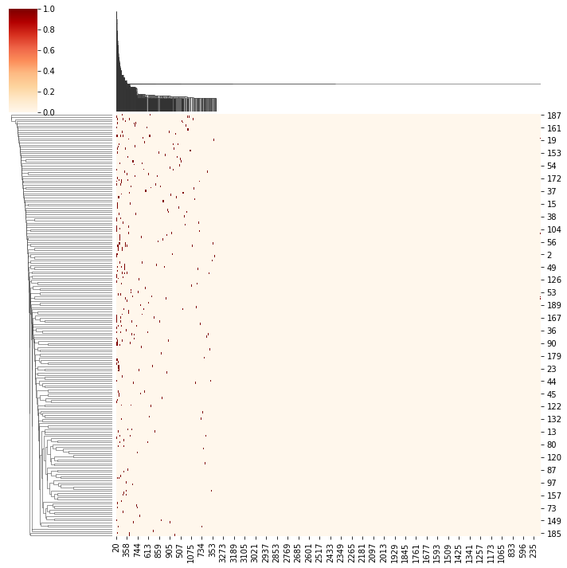

```python
sequences_label_binary_ = sequences_label_binary[0:10]
for line_ in sequences_label_binary_:
    line_ = list(line_)
    str_ = ''
    for index_ in range(len(line_)):
        if line_[index_] == 1:
            str_ = str_ + str(index_) +','
    print(str_)

sequences_label_binary_ = sequences_label_binary[0:200]
print(type(sequences_label_binary_), type(sequences_label_binary))
g1 = sns.clustermap(sequences_label_binary_, cmap="OrRd")
#sequences_label_binary_
plt.savefig("./pdf/befor_demension_cluster_200.pdf",dpi=600)
```

下面代码使用KMeans聚类的结果不是稳定的，而这是由于KMeans本身的算法决定的，详：周志华《机器学习》P203图9.2

但是，PCA的结果是稳定的

```
(2843, 64) [ 0.9179201  -0.9550114  -0.00492377  0.1115062   1.0467191   0.52243286
 -0.1242865  -0.37628388  0.8149354   0.02899987 -0.5091644   0.04220863
  0.05378252 -0.0213491  -0.29759306 -0.15900488 -0.02777405 -0.18707624
 -0.17959304  0.02616522 -0.22391042  0.0515594   0.06670176  0.04744154
 -0.08897302 -0.00663245  0.05965699  0.01068502 -0.06447929  0.10090136
 -0.0551994  -0.0460437   0.02573262 -0.07764299 -0.04200688  0.28925475
 -0.13614237 -0.02840545  0.04836882 -0.15396136  0.03284628  0.00313833
 -0.2493135  -0.02069614 -0.15776193 -0.42228538  0.27016684  0.183028
  0.07893428  0.15127312 -0.00909098  0.05047676 -0.20217009  0.00364044
  0.39042118  0.2558162  -0.09276424 -0.06048204 -0.16503875 -0.25775167
 -0.20075203  0.18090352  0.03530445  0.0609136 ]
```

```
array([143, 283,  42, ...,  95, 159,   5], dtype=int32)
```

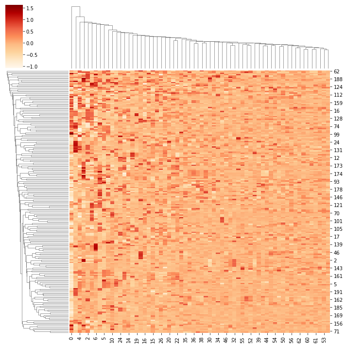

```python
from sklearn.cluster import KMeans
from sklearn.metrics import silhouette_score
from matplotlib import pyplot as plt
import pandas as pd
from sklearn.decomposition import PCA

pca = PCA(n_components=64)
data = sequences_label_binary
demensioned_data=pca.fit_transform(data)
print(demensioned_data.shape, demensioned_data[0])

g2 = sns.clustermap(demensioned_data[0:200], cmap="OrRd")
#plt.title('after_demension_cluster_200')
plt.savefig("./pdf/after_demension_cluster_200.pdf",dpi=600)

# 建立模型
#score = []
#k_means_data = sequences_label_binary[0:100]

# 依次计算 2 到 12 类的轮廓系数
'''
for i in range(30):
    print("%d"%(i+1),end='\r')
    model = k_means(demension_30_data, n_clusters=i + 300)
    score.append(silhouette_score(demension_30_data, model[1]))
'''
kmeans = KMeans(n_clusters=300, random_state=0).fit(demensioned_data)
kmeans.labels_
```

```
2843
[6, 11, 20, 2, 17, 24, 12, 8, 7, 4, 35, 13, 6, 10, 1, 7, 13, 12, 6, 15, 17, 3, 37, 3, 4, 28, 16, 3, 5, 12, 17, 5, 11, 16, 21, 16, 16, 9, 8, 10, 9, 22, 19, 63, 7, 10, 10, 12, 16, 11, 9, 9, 13, 6, 3, 24, 5, 2, 30, 7, 21, 2, 2, 24, 20, 15, 9, 11, 7, 21, 7, 40, 4, 10, 6, 14, 14, 23, 6, 12, 3, 6, 37, 18,…
```

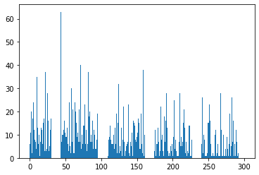

```python
#存放每个簇内部的2843条序列的对应编号
cluster_300_result = []
for i in range(300):
    cluster_300_result.append([])
for i in range(len(kmeans.labels_)):
    element = list(kmeans.labels_)[i]
    cluster_300_result[element].append(i)
cluster_300_result_L = []
for i in range(300):
    cluster_300_result_L.append(len(cluster_300_result[i]))

plt.bar(range(0, 300, 1), cluster_300_result_L)
print(np.sum(cluster_300_result_L))
print(cluster_300_result_L)
```

使用0/1背包策略划分8/1/1的训练验证测试集合

或者使用将300个簇按照体积降序排列，然后一直取序列为训练集直到取满0.8为止

```
2276 284 283
```

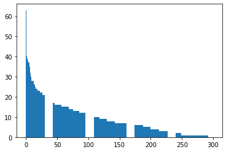

```python
cluster_300_result = sorted(cluster_300_result,key = lambda i:len(i),reverse=True)#令簇按照簇长度降序排序
cluster_300_result_L = []
for i in range(300):
    cluster_300_result_L.append(len(cluster_300_result[i]))
plt.bar(range(0, 300, 1), cluster_300_result_L)
#print(cluster_300_result_L)

all_indexes = set(range( len(sequences_label) ))
train_indexes = []
train_L = 0
for i in range(len(cluster_300_result)):
    if len(train_indexes) >=  0.8 * len(sequences_label):
        break
    else:
        for ele_ in cluster_300_result[i]:
            train_indexes.append(ele_)

import random
valid_indexes = random.sample( set(all_indexes)-set(train_indexes), int( 0.1 * len(sequences_label) ) )
test_indexes = list(
    set(range(len(sequences_label))) - set(train_indexes) - set(valid_indexes))

#print(train_indexes, valid_indexes, test_indexes)
#print(train_indexes)
print(
    len(list(np.unique(train_indexes)) ),
    len(list(np.unique(valid_indexes)) ),
    len(list(np.unique(test_indexes)) )
)
```

以上划分train / valid / test集合结束以后，就按照正常流程跑训练就行了

以下代码为之前流程计算jaccard系数划分基因家族的代码，将弃之不用

```python
print(jaccard_sim_result.shape)
jaccard_sim_result[1]
```

```
(2843, 2843)
```

```
array([0.06666667, 1.        , 0.03846154, ..., 0.        , 0.04166667,
       0.        ], dtype=float32)
```

```python
jaccard_pare = []
index_unique = []
count = 0
#jaccard_sim_result_table = pd.DataFrame(columns=['chrom_a','start_a','end_a','chrom_b','start_b','end_b','jaccard_sim'])
#筛选存在jaccard系数的序列对并添加进入jaccard_pare和index_unique->中途查询之用
for i in range(len(sorted_sequences_label)):
    for ii in range(len(sorted_sequences_label)):
        if i < ii and jaccard_sim_result[i,ii] > 0 and jaccard_sim_result[i,ii] < 1:
            #jaccard_sim_result_table.loc[count] = [ sequence_divition.iloc[i]['chrom'], sequence_divition.iloc[i]['start'], sequence_divition.iloc[i]['end'], sequence_divition.iloc[ii]['chrom'], sequence_divition.iloc[ii]['start'], sequence_divition.iloc[ii]['end'], jaccard_sim_result[i,ii] ]
            jaccard_pare.append([i,ii,jaccard_sim_result[i,ii]])
            count+=1
            index_unique.append(i)
            index_unique.append(ii)
            #print("[%d %d %d]"%(count,i,ii),end='\r')

# 获取列表的第3个元素
def takeSecond(elem):
    return elem[2]

# 指定第3个元素降序排序
jaccard_pare.sort(key=takeSecond, reverse=True)
#jaccard_pare

select_into_training_sequence_index = []
count = 0
while len(select_into_training_sequence_index) < 0.8*len(sequence_divition) and count < len(jaccard_pare):
    select_into_training_sequence_index.append(jaccard_pare[count][0])
    select_into_training_sequence_index.append(jaccard_pare[count][1])
    select_into_training_sequence_index = list(np.unique(select_into_training_sequence_index))
    count+=1
    print('%d'%(count),end='\r')
```

```
139557
```

```python
print(len(list(np.unique(index_unique))), len(jaccard_pare), len(select_into_training_sequence_index))
```

```
2841 2097647 2275
```

# 对jaccard系数聚类

```python
type(sorted_sequences_label)
```

```
list
```

```python
#the input a and b should all be list
def jaccard_sim(a, b):
    unions = len(set(a) & (set(b)))
    intersections = len(set(a) | (set(b)))
    #print(unions, intersections)
    if intersections == 0:
        return 0
    else:
        return 1. * unions / intersections

jaccard_sim_result = np.zeros((len(sorted_sequences_label),len(sorted_sequences_label)),dtype='float32')

for x in range(len(sorted_sequences_label)):
    for y in range(len(sorted_sequences_label)):
        jaccard_sim_result[x, y] = jaccard_sim(sorted_sequences_label[x],sorted_sequences_label[y])

jaccard_sim_result[0:10]
```

```
array([[1.        , 0.06666667, 0.07407407, ..., 0.07692308, 0.        ,
        0.06451613],
       [0.06666667, 1.        , 0.03846154, ..., 0.        , 0.04166667,
        0.        ],
       [0.07407407, 0.03846154, 1.        , ..., 0.        , 0.        ,
        0.03703704],
       ...,
       [0.1       , 0.03333334, 0.03703704, ..., 0.        , 0.        ,
        0.03225806],
       [0.07692308, 0.04      , 0.15      , ..., 0.        , 0.05      ,
        0.        ],
       [0.03846154, 0.        , 0.        , ..., 0.05      , 0.        ,
        0.08333334]], dtype=float32)
```

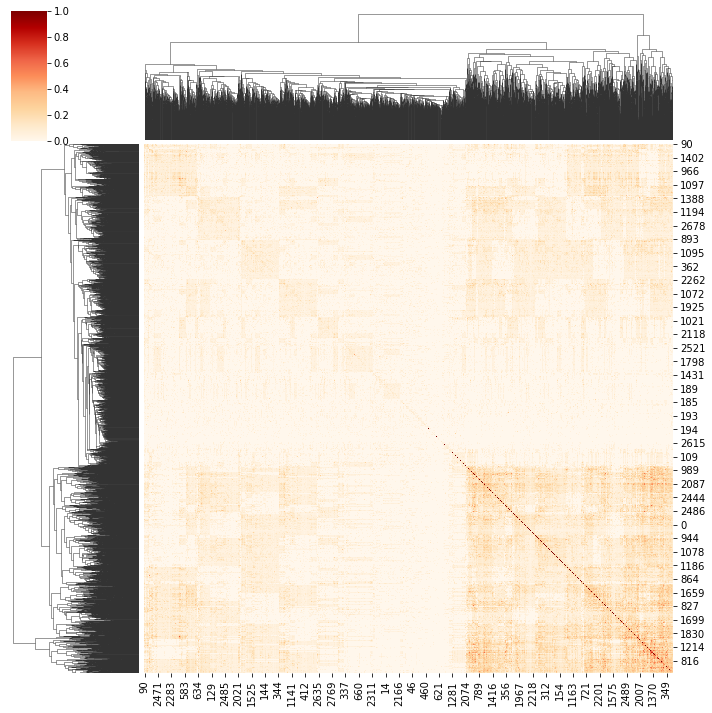

```python
g3 = sns.clustermap(jaccard_sim_result, cmap="OrRd")
#plt.savefig("./pdf/jaccard_result_clustering_200.pdf",dpi=600)
```

```python
!pwd
!ls ./pdf
```

```
/public/home/ztu/projects/alw_centos7/projects/master/gene_family_guided_training
after_demension_cluster_200.pdf
befor_demension_cluster_200.pdf
jaccard_result_clustering_200.pdf
performance_of_3models_3d_plot.pdf
performance_of_3models_bar_plot.pdf
performance_of_synteny_training_and_synteny_random_reference.pdf
```

按照每行（即每条序列为单位）,挑选指定阈值以上的序列集合成簇进行基因家族集成

# MH and NIP单倍型数据检验

```python
!ls ./csv
```

```
all_DIY.gff3				distinct_families.txt
all_DIY.gtf				famInfo.table.txt
all.pfam				final_used_zs_681_points.csv
all_pfam_gene_and_gene_family_list.bed	gene_list.bed
compare_selene_panicle_20samples.bed	gene_name.txt
```

```python
import numpy as np
import seaborn as sns
import matplotlib.pyplot as plt
import pandas as pd
comparison_data_map2NIP = pd.read_csv("./csv/final_used_zs_681_points.csv",sep=',')
```

```python
comparison_data_map2NIP
```

|  | vg_info | contig | position | variantID | refAllele | altAllele | refCount | altCount | totalCount | lowMAPQDepth | ... | improperPairs | pval | ref_freq | MH_MH_pred | MH_NIP_pred | NIP_NIP_pred | NIP_MH_pred | NIP_lsar | MH_lsar | nm_alt_ref |
| --- | --- | --- | --- | --- | --- | --- | --- | --- | --- | --- | --- | --- | --- | --- | --- | --- | --- | --- | --- | --- | --- |
| 0 | vg0100646215_C_G | chr01 | 646215 | vg0100646215 | C | G | 25 | 5 | 30 | 0 | ... | 0 | 4.077315e-03 | 0.833333 | 104.662121 | 105.561403 | 261.312084 | 259.838308 | -0.008267 | -0.012459 | -20 |
| 1 | vg0101880320_A_G | chr01 | 1880320 | vg0101880320 | A | G | 31 | 3 | 34 | 0 | ... | 1 | 4.649162e-06 | 0.911765 | 66.319158 | 65.444076 | 177.552972 | 186.729017 | 0.071003 | 0.018458 | -28 |
| 2 | vg0101880415_T_C | chr01 | 1880415 | vg0101880415 | T | C | 37 | 3 | 40 | 0 | ... | 0 | 1.233129e-07 | 0.925000 | 92.993759 | 95.849343 | 237.241916 | 231.511399 | -0.034585 | -0.042800 | -34 |
| 3 | vg0102142435_C_T | chr01 | 2142435 | vg0102142435 | C | T | 18 | 1 | 19 | 0 | ... | 3 | 1.449585e-04 | 0.947368 | 61.335384 | 64.866202 | 239.962782 | 225.816230 | -0.092143 | -0.078179 | -17 |
| 4 | vg0102176841_C_T | chr01 | 2176841 | vg0102176841 | C | T | 8 | 0 | 8 | 0 | ... | 0 | 7.812500e-03 | 1.000000 | 55.928676 | 56.191861 | 135.606601 | 135.165996 | -0.004940 | -0.006930 | -8 |
| ... | ... | ... | ... | ... | ... | ... | ... | ... | ... | ... | ... | ... | ... | ... | ... | ... | ... | ... | ... | ... | ... |
| 676 | vg1101292489_T_C | chr11 | 1292489 | vg1101292489 | T | C | 42 | 6 | 48 | 0 | ... | 1 | 2.828878e-06 | 0.875000 | 121.126095 | 117.410423 | 621.885123 | 632.111849 | 0.024687 | 0.043843 | -36 |
| 677 | vg1101292503_A_G | chr11 | 1292503 | vg1101292503 | A | G | 41 | 5 | 46 | 0 | ... | 2 | 7.841572e-07 | 0.891304 | 118.851181 | 117.520840 | 522.071473 | 528.733632 | 0.017630 | 0.015557 | -36 |
| 678 | vg1101292545_C_G | chr11 | 1292545 | vg1101292545 | C | G | 38 | 5 | 43 | 0 | ... | 1 | 4.255962e-06 | 0.883721 | 124.428254 | 119.756792 | 505.844393 | 517.526916 | 0.034122 | 0.052239 | -33 |
| 679 | vg1101292546_A_G | chr11 | 1292546 | vg1101292546 | A | G | 38 | 5 | 43 | 0 | ... | 1 | 4.255962e-06 | 0.883721 | 155.663394 | 148.866334 | 547.300541 | 565.892084 | 0.048068 | 0.061967 | -33 |
| 680 | vg1101292654_G_A | chr11 | 1292654 | vg1101292654 | G | A | 29 | 6 | 35 | 0 | ... | 1 | 2.315700e-03 | 0.828571 | 101.725934 | 107.970398 | 471.952397 | 446.672977 | -0.080492 | -0.084335 | -23 |

681 rows × 23 columns

```python
def generate_vcf_file(vg_table):
    out_nip_vcf_file = open('./csv/nip_genome_681_points.vcf','w')
    for i in range(len(vg_table)):
        str_ = ""+str(vg_table.iloc[i]['contig'])+'\t'+str(vg_table.iloc[i]['position'])+'\t'+str(vg_table.iloc[i]['variantID'])+'\t'+str(vg_table.iloc[i]['refAllele'])+'\t'+str(vg_table.iloc[i]['altAllele'])+'\t.'
        out_nip_vcf_file.write("%s\n"%str_)
generate_vcf_file(comparison_data_map2NIP)
```

```python
# /public/home/ztu/projects/lcming/compare_selene/sad
all_vcf_map2MH = pd.read_csv(
    "/public/home/ztu/projects/lcming/compare_selene/sad/MH_NIP_site_mapped2MH.vcf",
    sep='\t',
    names = ['chrom', 'position', 'variantID', 'ref', 'alt', 'annotation']
)
all_vcf_map2MH
```

|  | chrom | position | variantID | ref | alt | annotation |
| --- | --- | --- | --- | --- | --- | --- |
| 0 | chr08 | 14702 | vg0800001503 | A | G | . |
| 1 | chr08 | 14714 | vg0800001515 | G | T | . |
| 2 | chr08 | 14722 | vg0800001523 | C | T | . |
| 3 | chr08 | 17250 | vg0800004053 | A | T | . |
| 4 | chr08 | 17255 | vg0800004058 | G | T | . |
| ... | ... | ... | ... | ... | ... | ... |
| 1171362 | chr10 | 25054361 | vg1023204854 | T | C | . |
| 1171363 | chr10 | 25054794 | vg1023205287 | T | C | . |
| 1171364 | chr10 | 25054879 | vg1023205372 | A | G | . |
| 1171365 | chr10 | 25055318 | vg1023205811 | T | G | . |
| 1171366 | chr10 | 25055371 | vg1023205864 | A | G | . |

1171367 rows × 6 columns

```python
out_grep_mh_vcf_file = open('./csv/grep_mh_genome_681_points.sh','w')
for vg in comparison_data_map2NIP.variantID:
    str_ = "cat MH_NIP_site_mapped2MH.vcf |grep "+vg+" >> mh_genome_681_points.vcf"
    out_grep_mh_vcf_file.write("%s\n"%str_)
```

```python
basenji_pca_model_mh = pd.read_csv(
    "/public/home/ztu/projects/lcming/compare_selene/gene_family_models_sad/sad_result/mh/pca_kmeans_cluster_synteny_training_model/sad_table.txt",
    sep='\t'
)
basenji_pca_model_nip = pd.read_csv(
    "/public/home/ztu/projects/lcming/compare_selene/gene_family_models_sad/sad_result/nip/pca_kmeans_cluster_synteny_training_model/sad_table.txt",
    sep='\t'
)

sample_name = ['C003', 'C004', 'C007', 'C008', 'C010', 'C013', 'C014', 'C015', 'C022', 'C025',
               'W001', 'W002', 'W003', 'W009', 'W010', 'W026', 'W035', 'W039', 'W041', 'W044']
```

```python
basenji_pca_model_mh.head()
```

|  | rsid | ref | alt | ref_pred | alt_pred | sad | sar | geo_sad | ref_lpred | alt_lpred | lsad | lsar | ref_xpred | alt_xpred | xsad | xsar | target_index | target_id | target_label |
| --- | --- | --- | --- | --- | --- | --- | --- | --- | --- | --- | --- | --- | --- | --- | --- | --- | --- | --- | --- |
| 0 | vg0100646215 | G | C | 128842.82 | 128895.81 | 52.995 | 0.0006 | 0.256 | 2038.262 | 2063.375 | 25.113 | 0.0177 | 236.438 | 241.587 | 5.149 | 0.0309 | 0 | C003_q30 | C003_q30 |
| 1 | vg0100646215 | G | C | 132409.21 | 132467.59 | 58.382 | 0.0006 | 0.267 | 2317.649 | 2346.540 | 28.891 | 0.0179 | 287.140 | 293.672 | 6.531 | 0.0323 | 1 | C004_q30 | C004_q30 |
| 2 | vg0100646215 | G | C | 133814.05 | 133872.27 | 58.225 | 0.0006 | 0.273 | 2340.559 | 2371.879 | 31.320 | 0.0192 | 286.793 | 293.894 | 7.101 | 0.0352 | 2 | C007_q30 | C007_q30 |
| 3 | vg0100646215 | G | C | 132686.95 | 132746.25 | 59.300 | 0.0006 | 0.264 | 2481.487 | 2513.575 | 32.089 | 0.0185 | 310.586 | 317.853 | 7.267 | 0.0333 | 3 | C008_q30 | C008_q30 |
| 4 | vg0100646215 | G | C | 126509.70 | 126565.60 | 55.905 | 0.0006 | 0.266 | 2167.611 | 2196.107 | 28.495 | 0.0188 | 270.101 | 276.577 | 6.475 | 0.0341 | 4 | C010_q30 | C010_q30 |

```python
basenji_pca_model_nip.head()
```

|  | rsid | ref | alt | ref_pred | alt_pred | sad | sar | geo_sad | ref_lpred | alt_lpred | lsad | lsar | ref_xpred | alt_xpred | xsad | xsar | target_index | target_id | target_label |
| --- | --- | --- | --- | --- | --- | --- | --- | --- | --- | --- | --- | --- | --- | --- | --- | --- | --- | --- | --- |
| 0 | vg0100646215 | C | G | 142197.58 | 142133.69 | -63.888 | -0.0006 | -0.267 | 2609.868 | 2579.350 | -30.518 | -0.0170 | 295.458 | 289.840 | -5.618 | -0.0276 | 0 | C003_q30 | C003_q30 |
| 1 | vg0100646215 | C | G | 146907.12 | 146839.80 | -67.320 | -0.0007 | -0.274 | 2910.489 | 2876.428 | -34.061 | -0.0170 | 364.017 | 357.014 | -7.003 | -0.0279 | 1 | C004_q30 | C004_q30 |
| 2 | vg0100646215 | C | G | 151263.70 | 151192.55 | -71.157 | -0.0007 | -0.286 | 2977.311 | 2939.900 | -37.411 | -0.0182 | 362.088 | 354.513 | -7.575 | -0.0304 | 2 | C007_q30 | C007_q30 |
| 3 | vg0100646215 | C | G | 150260.61 | 150188.23 | -72.374 | -0.0007 | -0.283 | 3106.197 | 3068.364 | -37.833 | -0.0177 | 381.093 | 373.390 | -7.703 | -0.0294 | 3 | C008_q30 | C008_q30 |
| 4 | vg0100646215 | C | G | 138996.03 | 138927.88 | -68.152 | -0.0007 | -0.277 | 2801.934 | 2767.004 | -34.930 | -0.0181 | 342.460 | 335.311 | -7.149 | -0.0303 | 4 | C010_q30 | C010_q30 |

```python
print(
    len ( list( basenji_pca_model_mh['ref_lpred'] - basenji_pca_model_nip['ref_lpred'] ) ),
    len( comparison_data_map2NIP.nm_alt_ref )
)
```

```
13620 681
```

```python
def p681_evaluate(mh_table, nip_table, save_pic):
    scale_x = 4
    scale_y = int(len(sample_name)/scale_x)
    fig, axs = plt.subplots(scale_x, scale_y, figsize=(20,15))
    basenji_precision = []
    for sample in sample_name:
        selected_ = []
        i = sample_name.index(sample)
        while i < len(basenji_pca_model_mh):
            selected_.append(mh_table.iloc[i]['ref_lpred'] - nip_table.iloc[i]['ref_lpred'])
            i=i+len(sample_name)

        from kern_smooth import densCols
        from matplotlib.colors import ListedColormap
        densities = densCols(selected_, comparison_data_map2NIP.nm_alt_ref, nbin=50)
        index = sample_name.index(sample)
        axs[int(index/scale_y),int(index%scale_y)].scatter(selected_, comparison_data_map2NIP.nm_alt_ref,
                s=8,c=densities,alpha=1,cmap=ListedColormap(sns.color_palette("RdBu_r", 7).as_hex()),rasterized=True)
        #axs[int(index/scale_y),int(index%scale_y)].set_ylabel('nm_alt_ref')
        count = 0
        for i in range(len(comparison_data_map2NIP.nm_alt_ref)):
            if(selected_[i] * comparison_data_map2NIP.nm_alt_ref[i] > 0):
                count=count+1
        from scipy.stats import pearsonr
        r,_ = pearsonr(selected_, comparison_data_map2NIP.nm_alt_ref)
        print("%s : %0.3f , %0.3f"%(sample, count/float(len(comparison_data_map2NIP.nm_alt_ref)), r**2))
        axs[int(index/scale_y),int(index%scale_y)].set_title(r'%s : %0.3f' %(sample,count/float(len(comparison_data_map2NIP.nm_alt_ref))))
        axs[int(index/scale_y),int(index%scale_y)].axvline(x=0,c='grey',linestyle='--')
        axs[int(index/scale_y),int(index%scale_y)].axhline(y=0,c='grey',linestyle='--')
        basenji_precision.append(count/float(len(comparison_data_map2NIP.nm_alt_ref)))
    #plt.suptitle('basenji_precision')
    if save_pic is not None:
        plt.savefig(save_pic,dpi=600)

    model_precision = basenji_precision#改个变量名，防止误解
    return model_precision
```

对synteny_training模型评估

```
C003 : 0.827 , 0.247
C004 : 0.821 , 0.245
C007 : 0.806 , 0.211
C008 : 0.814 , 0.223
C010 : 0.825 , 0.245
C013 : 0.822 , 0.219
C014 : 0.833 , 0.259
C015 : 0.821 , 0.221
C022 : 0.802 , 0.210
C025 : 0.811 , 0.217
W001 : 0.821 , 0.226
W002 : 0.821 , 0.237
W003 : 0.822 , 0.244
W009 : 0.806 , 0.208
W010 : 0.825 , 0.240
W026 : 0.806 , 0.213
W035 : 0.814 , 0.219
W039 : 0.819 , 0.220
W041 : 0.822 , 0.244
W044 : 0.805 , 0.210
```

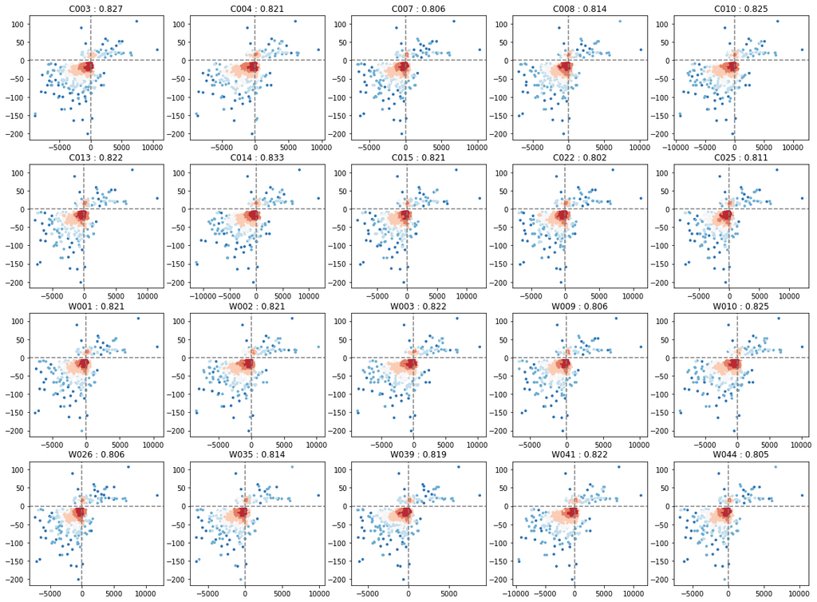

```python
basenji_synteny_training_model_mh = pd.read_csv(
    "/public/home/ztu/projects/lcming/compare_selene/gene_family_models_sad/sad_result/mh/synteny_training_panicle_20samples_model/sad_table.txt",
    sep='\t'
)
basenji_synteny_training_model_nip = pd.read_csv(
    "/public/home/ztu/projects/lcming/compare_selene/gene_family_models_sad/sad_result/nip/synteny_training_panicle_20samples_model/sad_table.txt",
    sep='\t'
)
synteny_training_precision = p681_evaluate(basenji_synteny_training_model_mh, basenji_synteny_training_model_nip, './pdf/synteny_training_model_681_points.pdf')
```

对PCA模型的评估

```
C003 : 0.834 , 0.203
C004 : 0.836 , 0.204
C007 : 0.821 , 0.189
C008 : 0.818 , 0.196
C010 : 0.841 , 0.205
C013 : 0.821 , 0.194
C014 : 0.847 , 0.216
C015 : 0.816 , 0.192
C022 : 0.812 , 0.186
C025 : 0.819 , 0.192
W001 : 0.819 , 0.200
W002 : 0.836 , 0.198
W003 : 0.852 , 0.206
W009 : 0.812 , 0.186
W010 : 0.840 , 0.200
W026 : 0.821 , 0.191
W035 : 0.827 , 0.195
W039 : 0.827 , 0.195
W041 : 0.834 , 0.203
W044 : 0.815 , 0.188
```

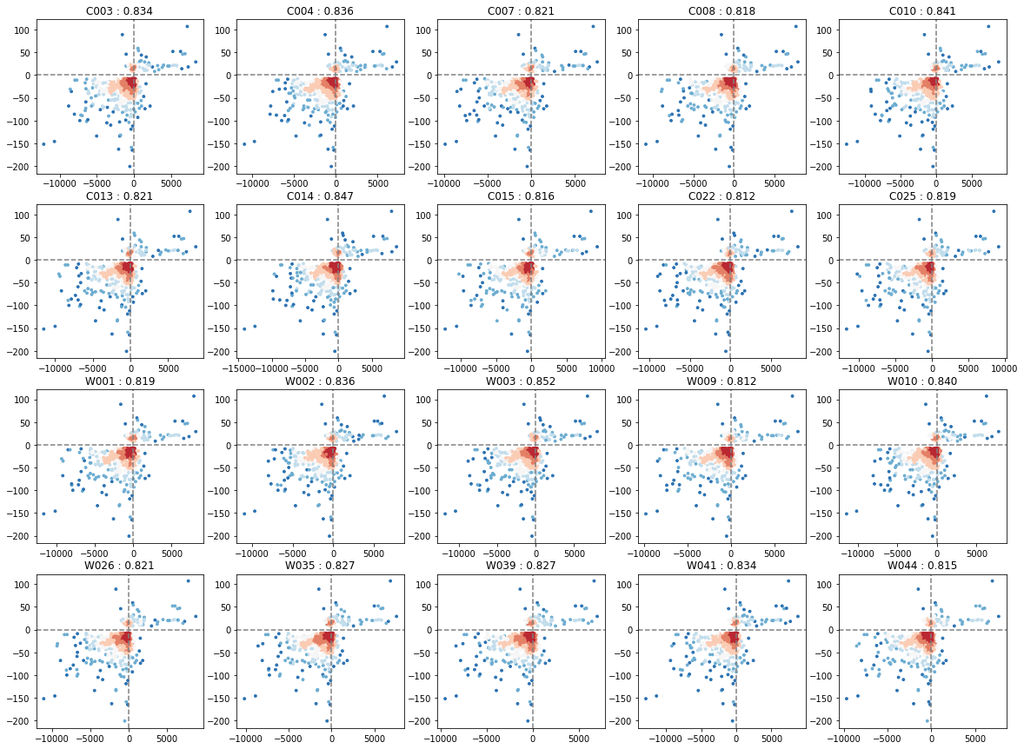

```python
pca_model_precision = p681_evaluate(basenji_pca_model_mh, basenji_pca_model_nip, './pdf/pca_model_681_points.pdf')
```

对random_reference模型的评估

```
C003 : 0.803 , 0.233
C004 : 0.814 , 0.236
C007 : 0.783 , 0.190
C008 : 0.780 , 0.201
C010 : 0.811 , 0.237
C013 : 0.786 , 0.200
C014 : 0.819 , 0.253
C015 : 0.783 , 0.201
C022 : 0.781 , 0.188
C025 : 0.784 , 0.194
W001 : 0.784 , 0.207
W002 : 0.802 , 0.226
W003 : 0.818 , 0.237
W009 : 0.780 , 0.186
W010 : 0.809 , 0.229
W026 : 0.781 , 0.193
W035 : 0.790 , 0.202
W039 : 0.784 , 0.202
W041 : 0.805 , 0.234
W044 : 0.781 , 0.188
```

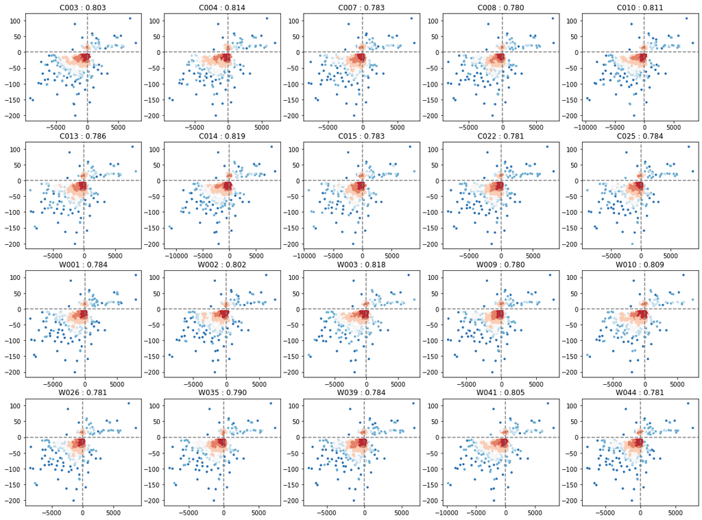

```python
basenji_random_reference_model_mh = pd.read_csv(
    "/public/home/ztu/projects/lcming/compare_selene/gene_family_models_sad/sad_result/mh/synteny_random_reference_panicle_20samples_model/sad_table.txt",
    sep='\t'
)
basenji_random_reference_model_nip = pd.read_csv(
    "/public/home/ztu/projects/lcming/compare_selene/gene_family_models_sad/sad_result/nip/synteny_random_reference_panicle_20samples_model/sad_table.txt",
    sep='\t'
)
random_reference_precision = p681_evaluate(basenji_random_reference_model_mh, basenji_random_reference_model_nip, './pdf/random_reference_model_681_points.pdf')
```

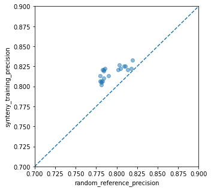

```python
f, ax=plt.subplots(figsize=(5, 4.5))
#densities = densCols(selene_precision, basenji_precision,nbin = 10)
#ax.scatter(selene_precision, basenji_precision,c=densities, s=10, edgecolors='none', alpha=0.75,cmap=sns.diverging_palette(240, 0,as_cmap=True))
ax.scatter(random_reference_precision, synteny_training_precision, alpha=0.5)
ax.plot([0, 1], [0, 1], transform=ax.transAxes, ls='--')
ax.set_xlabel('random_reference_precision')
ax.set_ylabel('synteny_training_precision')
plt.xlim(0.7,0.9)
plt.ylim(0.7,0.9)
plt.tight_layout()
```

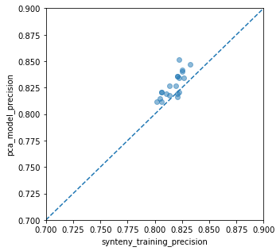

```python
f, ax=plt.subplots(figsize=(5, 4.5))
#densities = densCols(selene_precision, basenji_precision,nbin = 10)
#ax.scatter(selene_precision, basenji_precision,c=densities, s=10, edgecolors='none', alpha=0.75,cmap=sns.diverging_palette(240, 0,as_cmap=True))
ax.scatter(synteny_training_precision, pca_model_precision, alpha=0.5)
ax.plot([0, 1], [0, 1], transform=ax.transAxes, ls='--')
ax.set_xlabel('synteny_training_precision')
ax.set_ylabel('pca_model_precision')
plt.xlim(0.7,0.9)
plt.ylim(0.7,0.9)
plt.tight_layout()
```

以下为尝试性分析，不重要

```
0.7951655982905983 0.9397944199706314
```

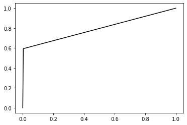

```python
import sklearn
e = []
p = []
count = 0
for i in range(len(comparison_data_map2NIP.MH_MH_pred - comparison_data_map2NIP.NIP_NIP_pred)):
    if (comparison_data_map2NIP.MH_MH_pred - comparison_data_map2NIP.NIP_NIP_pred).iloc[i] > 0:
        p.append(True)
    else:
        p.append(False)
    if (comparison_data_map2NIP.nm_alt_ref).iloc[i] * (comparison_data_map2NIP.MH_MH_pred - comparison_data_map2NIP.NIP_NIP_pred).iloc[i] > 0:
        count = count + 1
for i in range(len(comparison_data_map2NIP.nm_alt_ref)):
    if (comparison_data_map2NIP.nm_alt_ref).iloc[i] > 0:
        e.append(True)
    else:
        e.append(False)
fpr, tpr, _ = sklearn.metrics.roc_curve(e, p)
plt.plot(fpr, tpr, c='black')
print(sklearn.metrics.roc_auc_score(e, p), 1.0*count/len(comparison_data_map2NIP.nm_alt_ref) )
```

# 比较三个模型的性能

synteny_training_result是使用 https://funricegenes.github.io/famInfo.table.txt 计算jaccard系数划分基因家族训练的结果；

synteny_random_reference_result是随机划分序列的对照组

```python
import numpy as np
import seaborn as sns
import matplotlib.pyplot as plt
import pandas as pd

synteny_training_result = pd.read_csv(
    '/public/home/ztu/projects/lcming/compare_selene/test/synteny_training_panicle_20samples_model/synteny_training_panicle_20samples_model_eval.csv',
    sep=','
)
pca_kmeans_cluster_synteny_result = pd.read_csv(
    '/public/home/ztu/projects/lcming/compare_selene/test/pca_kmeans_cluster_synteny_training_model/pca_kmeans_cluster_synteny_training_model_eval.csv',
    sep=','
)
synteny_random_reference_result = pd.read_csv(
    '/public/home/ztu/projects/lcming/compare_selene/test/synteny_random_reference_panicle_20samples_model/synteny_random_reference_panicle_20samples_model_eval.csv',
    sep=','
)
synteny_training_result
```

|  | index | r2 | prc | auc |
| --- | --- | --- | --- | --- |
| 0 | 0 | 0.647851 | 0.777383 | 0.924877 |
| 1 | 1 | 0.591443 | 0.765820 | 0.919800 |
| 2 | 2 | 0.646293 | 0.764856 | 0.901667 |
| 3 | 3 | 0.674928 | 0.767603 | 0.909579 |
| 4 | 4 | 0.639810 | 0.751074 | 0.914449 |
| 5 | 5 | 0.702890 | 0.000100 | 0.706638 |
| 6 | 6 | 0.634790 | 0.765561 | 0.923930 |
| 7 | 7 | 0.603820 | 0.760222 | 0.914295 |
| 8 | 8 | 0.667640 | 0.756701 | 0.904424 |
| 9 | 9 | 0.670098 | 0.763100 | 0.910660 |
| 10 | 10 | 0.678510 | 0.764982 | 0.905768 |
| 11 | 11 | 0.604680 | 0.754399 | 0.907932 |
| 12 | 12 | 0.626248 | 0.753866 | 0.909728 |
| 13 | 13 | 0.599456 | 0.761120 | 0.901567 |
| 14 | 14 | 0.666767 | 0.792909 | 0.928984 |
| 15 | 15 | 0.658350 | 0.768225 | 0.911189 |
| 16 | 16 | 0.606260 | 0.778730 | 0.914037 |
| 17 | 17 | 0.679834 | 0.779544 | 0.910144 |
| 18 | 18 | 0.674217 | 0.765044 | 0.925554 |
| 19 | 19 | 0.652588 | 0.762249 | 0.902550 |

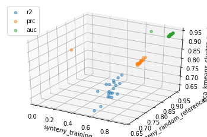

```python
ax = plt.axes(projection='3d')
ax.scatter3D(
    synteny_training_result['r2'],
    synteny_random_reference_result['r2'],
    pca_kmeans_cluster_synteny_result['r2'],
    #c=synteny_training_result['r2'],
    alpha=0.5,
    label="r2"
)
ax.scatter3D(
    synteny_training_result['prc'],
    synteny_random_reference_result['prc'],
    pca_kmeans_cluster_synteny_result['prc'],
    #c=synteny_training_result['prc'],
    alpha=0.5,
    label="prc"
)
ax.scatter3D(
    synteny_training_result['auc'],
    synteny_random_reference_result['auc'],
    pca_kmeans_cluster_synteny_result['auc'],
    #c=synteny_training_result['auc'],
    alpha=0.5,
    label="auc"
)
ax.set_xlabel('synteny_training')
ax.set_ylabel('synteny_random_reference')
ax.set_zlabel('pca_kmeans_cluster_synteny')
plt.legend()#显示label
plt.savefig("pdf/performance_of_3models_3d_plot.pdf",dpi=600)
```

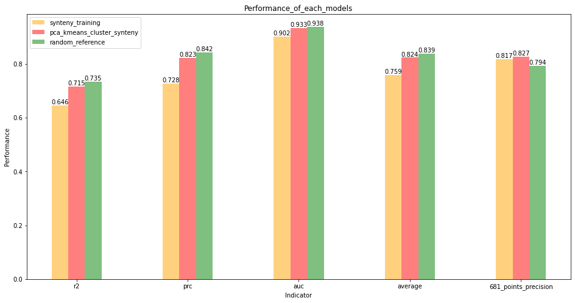

```python
#name_list = ['synteny_training','pca_kmeans_cluster_synteny','synteny_random_reference']
name_list = ['r2','prc','auc','average','681_points_precision']
synteny_training = [
    synteny_training_result['r2'].mean(),
    synteny_training_result['prc'].mean(),
    synteny_training_result['auc'].mean(),
    (synteny_training_result['r2'].mean()+synteny_training_result['prc'].mean()+synteny_training_result['auc'].mean())/3,
    np.mean(synteny_training_precision)
]
pca_kmeans_cluster_synteny = [
    pca_kmeans_cluster_synteny_result['r2'].mean(),
    pca_kmeans_cluster_synteny_result['prc'].mean(),
    pca_kmeans_cluster_synteny_result['auc'].mean(),
    (pca_kmeans_cluster_synteny_result['r2'].mean()+pca_kmeans_cluster_synteny_result['prc'].mean()+pca_kmeans_cluster_synteny_result['auc'].mean())/3,
    np.mean(pca_model_precision)
]
random_reference = [
    synteny_random_reference_result['r2'].mean(),
    synteny_random_reference_result['prc'].mean(),
    synteny_random_reference_result['auc'].mean(),
    (synteny_random_reference_result['r2'].mean()+synteny_random_reference_result['prc'].mean()+synteny_random_reference_result['auc'].mean())/3,
    np.mean(random_reference_precision)
]
x = np.arange(len(name_list))
bar_width = 0.15

plt.figure(figsize=(16,8))
for a,b,c,d in zip(x, synteny_training, pca_kmeans_cluster_synteny, random_reference):
    plt.text(a,b,'%.3f' %b, ha='center',va='bottom')
    plt.text(a+bar_width,c,'%.3f' %c, ha='center',va='bottom')
    plt.text(a+bar_width*2,d,'%.3f' %d, ha='center',va='bottom')

# 有几个模型就写几句bar plot
plt.bar(x, synteny_training, bar_width, align="center", color="orange", label="synteny_training", alpha=0.5)
plt.bar(x+bar_width, pca_kmeans_cluster_synteny, bar_width, color="red", align="center", label="pca_kmeans_cluster_synteny", alpha=0.5)
plt.bar(x+bar_width*2, random_reference, bar_width, color="green", align="center", label="random_reference", alpha=0.5)

plt.xticks(x+bar_width*1.0, name_list)
#plt.xticks(rotation=6)

plt.xlabel("Indicator")
plt.ylabel("Performance")
plt.title('Performance_of_each_models')
plt.legend(loc='upper left')

plt.savefig("./pdf/performance_of_3models_bar_plot.pdf",dpi=600)
```